# Question

Considere os diagramas de caixa para três variáveis quantitativas contínuas de uma amostra representadas nas figuras A, B e C. Com base nessas figuras, marque apenas as alternativas correta (uma alternativa errada cancela a alternativa correta):

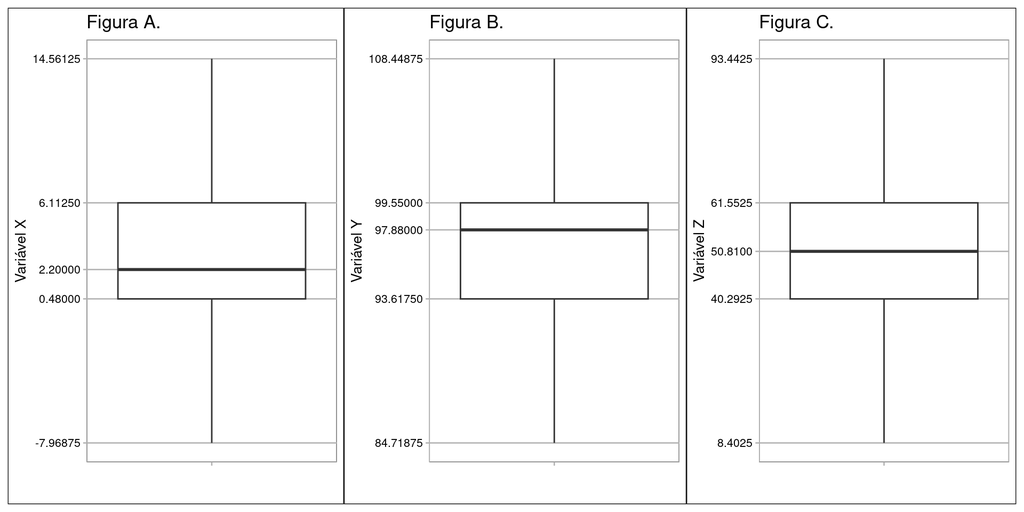

## Answerlist

- A variável quantitativa contínua X tem assimetria à direita ou positiva.
- A variável quantitativa contínua X tem assimetria à esquerda ou negativa.
- A variável quantitativa contínua X tem simetria.
- A variável quantitativa contínua Y tem assimetria à direita ou positiva.
- A variável quantitativa contínua Y tem assimetria à esquerda ou negativa.
- A variável quantitativa contínua Y tem simetria.
- A variável quantitativa contínua Z tem assimetria à direita ou positiva.
- A variável quantitativa contínua Z tem assimetria à esquerda ou negativa.
- A variável quantitativa contínua Z tem simetria.

# Solution

## Answerlist

- **Verdadeiro**. A variável quantitativa contínua X tem assimetria à direita ou positiva.
- **Falso**. A variável quantitativa contínua X **não** tem assimetria à esquerda ou negativa.
- **Falso**. A variável quantitativa contínua X **não** tem simetria.
- **Falso**. A variável quantitativa contínua Y **não** tem assimetria à direita ou positiva.
- **Verdadeiro**. A variável quantitativa contínua Y tem assimetria à esquerda ou negativa.
- **Falso**. A variável quantitativa contínua Y **não** tem simetria.
- **Falso**. A variável quantitativa contínua Z **não** tem assimetria à direita ou positiva.
- **Falso**. A variável quantitativa contínua Z **não** tem assimetria à esquerda ou negativa.
- **Verdadeiro**. A variável quantitativa contínua Z tem simetria.

# Meta-information

exname: diagramaCaixaAssimetria extype: mchoice exsolution: 100010001